# Housing Data Exploratory Analysis

Mark Gingrass

July 28, 2018

# Exploring Housing Data

### Data Descriptions

- SalePrice - the property’s sale price in dollars. This is the target variable that you’re trying to predict.
- MSSubClass: The building class
- MSZoning: The general zoning classification
- LotFrontage: Linear feet of street connected to property
- LotArea: Lot size in square feet
- Street: Type of road access
- Alley: Type of alley access
- LotShape: General shape of property
- LandContour: Flatness of the property
- Utilities: Type of utilities available
- LotConfig: Lot configuration
- LandSlope: Slope of property
- Neighborhood: Physical locations within Ames city limits
- Condition1: Proximity to main road or railroad
- Condition2: Proximity to main road or railroad (if a second is present)
- BldgType: Type of dwelling
- HouseStyle: Style of dwelling
- OverallQual: Overall material and finish quality
- OverallCond: Overall condition rating
- YearBuilt: Original construction date
- YearRemodAdd: Remodel date
- RoofStyle: Type of roof
- RoofMatl: Roof material
- Exterior1st: Exterior covering on house
- Exterior2nd: Exterior covering on house (if more than one material)
- MasVnrType: Masonry veneer type
- MasVnrArea: Masonry veneer area in square feet
- ExterQual: Exterior material quality
- ExterCond: Present condition of the material on the exterior
- Foundation: Type of foundation
- BsmtQual: Height of the basement
- BsmtCond: General condition of the basement
- BsmtExposure: Walkout or garden level basement walls
- BsmtFinType1: Quality of basement finished area
- BsmtFinSF1: Type 1 finished square feet
- BsmtFinType2: Quality of second finished area (if present)
- BsmtFinSF2: Type 2 finished square feet
- BsmtUnfSF: Unfinished square feet of basement area
- TotalBsmtSF: Total square feet of basement area
- Heating: Type of heating
- HeatingQC: Heating quality and condition
- CentralAir: Central air conditioning
- Electrical: Electrical system
- 1stFlrSF: First Floor square feet
- 2ndFlrSF: Second floor square feet
- LowQualFinSF: Low quality finished square feet (all floors)
- GrLivArea: Above grade (ground) living area square feet
- BsmtFullBath: Basement full bathrooms
- BsmtHalfBath: Basement half bathrooms
- FullBath: Full bathrooms above grade
- HalfBath: Half baths above grade
- Bedroom: Number of bedrooms above basement level
- Kitchen: Number of kitchens
- KitchenQual: Kitchen quality
- TotRmsAbvGrd: Total rooms above grade (does not include bathrooms)
- Functional: Home functionality rating
- Fireplaces: Number of fireplaces
- FireplaceQu: Fireplace quality
- GarageType: Garage location
- GarageYrBlt: Year garage was built
- GarageFinish: Interior finish of the garage
- GarageCars: Size of garage in car capacity
- GarageArea: Size of garage in square feet
- GarageQual: Garage quality
- GarageCond: Garage condition
- PavedDrive: Paved driveway
- WoodDeckSF: Wood deck area in square feet
- OpenPorchSF: Open porch area in square feet
- EnclosedPorch: Enclosed porch area in square feet
- 3SsnPorch: Three season porch area in square feet
- ScreenPorch: Screen porch area in square feet
- PoolArea: Pool area in square feet
- PoolQC: Pool quality
- Fence: Fence quality
- MiscFeature: Miscellaneous feature not covered in other categories
- : $Value of miscellaneous feature
- MoSold: Month Sold
- YrSold: Year Sold
- SaleType: Type of sale
- SaleCondition: Condition of sale

```r
load.libraries <- c('data.table', 'testthat', 'gridExtra', 'corrplot', 'GGally', 'ggplot2', 'e1071', 'dplyr', 'DT', 'tidyr', 'purrr', 'mi')
sapply(load.libraries, require, character = TRUE)
```

```
## data.table   testthat  gridExtra   corrplot     GGally    ggplot2
##       TRUE       TRUE       TRUE       TRUE       TRUE       TRUE
##      e1071      dplyr         DT      tidyr      purrr         mi
##       TRUE       TRUE       TRUE       TRUE       TRUE       TRUE
```

## Load train/test Data

If you have not used *fread* - it’s a way to read in a file directly to a data.table as opposed to a data.frame.

Track the catagorical feature names separately from the numeric feature names.

```r
cat_var <- names(train)[which(sapply(train, is.character))]
numeric_var <- names(train)[which(sapply(train, is.numeric))]
```

## Structure of the data

The housing data set has 1460 rows and 81 features with the target feature Sale Price. Note the structure of the data in the next tab - treating all factors as characters for now.

### Dimensions

```r
dim(train)
```

```
## [1] 1460   81
```

```r
DT::datatable(head(train))
```

|  | Id | MSSubClass | MSZoning | LotFrontage | LotArea | Street | Alley | LotShape | LandContour | Utilities | LotConfig | LandSlope | Neighborhood | Condition1 | Condition2 | BldgType | HouseStyle | OverallQual | OverallCond | YearBuilt | YearRemodAdd | RoofStyle | RoofMatl | Exterior1st | Exterior2nd | MasVnrType | MasVnrArea | ExterQual | ExterCond | … |
| --- | --- | --- | --- | --- | --- | --- | --- | --- | --- | --- | --- | --- | --- | --- | --- | --- | --- | --- | --- | --- | --- | --- | --- | --- | --- | --- | --- | --- | --- | --- |
| 1 | 1 | 60 | RL | 65 | 8450 | Pave |  | Reg | Lvl | AllPub | Inside | Gtl | CollgCr | Norm | Norm | 1Fam | 2Story | 7 | 5 | 2003 | 2003 | Gable | CompShg | VinylSd | VinylSd | BrkFace | 196 | Gd | TA | … |
| 2 | 2 | 20 | RL | 80 | 9600 | Pave |  | Reg | Lvl | AllPub | FR2 | Gtl | Veenker | Feedr | Norm | 1Fam | 1Story | 6 | 8 | 1976 | 1976 | Gable | CompShg | MetalSd | MetalSd | None | 0 | TA | TA | … |
| 3 | 3 | 60 | RL | 68 | 11250 | Pave |  | IR1 | Lvl | AllPub | Inside | Gtl | CollgCr | Norm | Norm | 1Fam | 2Story | 7 | 5 | 2001 | 2002 | Gable | CompShg | VinylSd | VinylSd | BrkFace | 162 | Gd | TA | … |
| 4 | 4 | 70 | RL | 60 | 9550 | Pave |  | IR1 | Lvl | AllPub | Corner | Gtl | Crawfor | Norm | Norm | 1Fam | 2Story | 7 | 5 | 1915 | 1970 | Gable | CompShg | Wd Sdng | Wd Shng | None | 0 | TA | TA | … |
| 5 | 5 | 60 | RL | 84 | 14260 | Pave |  | IR1 | Lvl | AllPub | FR2 | Gtl | NoRidge | Norm | Norm | 1Fam | 2Story | 8 | 5 | 2000 | 2000 | Gable | CompShg | VinylSd | VinylSd | BrkFace | 350 | Gd | TA | … |
| 6 | 6 | 50 | RL | 85 | 14115 | Pave |  | IR1 | Lvl | AllPub | Inside | Gtl | Mitchel | Norm | Norm | 1Fam | 1.5Fin | 5 | 5 | 1993 | 1995 | Gable | CompShg | VinylSd | VinylSd | None | 0 | TA | TA | … |

### Structure

```r
# Dimensions
dim(train)
```

```
## [1] 1460   81
```

```r
# Structure
str(train)
```

```
## Classes 'data.table' and 'data.frame':   1460 obs. of  81 variables:
##  $ Id           : int  1 2 3 4 5 6 7 8 9 10 ...
##  $ MSSubClass   : int  60 20 60 70 60 50 20 60 50 190 ...
##  $ MSZoning     : chr  "RL" "RL" "RL" "RL" ...
##  $ LotFrontage  : int  65 80 68 60 84 85 75 NA 51 50 ...
##  $ LotArea      : int  8450 9600 11250 9550 14260 14115 10084 10382 6120 7420 ...
##  $ Street       : chr  "Pave" "Pave" "Pave" "Pave" ...
##  $ Alley        : chr  NA NA NA NA ...
##  $ LotShape     : chr  "Reg" "Reg" "IR1" "IR1" ...
##  $ LandContour  : chr  "Lvl" "Lvl" "Lvl" "Lvl" ...
##  $ Utilities    : chr  "AllPub" "AllPub" "AllPub" "AllPub" ...
##  $ LotConfig    : chr  "Inside" "FR2" "Inside" "Corner" ...
##  $ LandSlope    : chr  "Gtl" "Gtl" "Gtl" "Gtl" ...
##  $ Neighborhood : chr  "CollgCr" "Veenker" "CollgCr" "Crawfor" ...
##  $ Condition1   : chr  "Norm" "Feedr" "Norm" "Norm" ...
```

[output cut: 68 more lines]

## Missing Values

```r
# Count NAs
na_counts <-lapply(train, function(x) sum(is.na(x)))

na_counts <- melt(na_counts)

names(na_counts) <- c("Number_NAs", "Attribute")
na_counts <- na_counts[which(na_counts$Number_NAs > 0),]

na_counts$Percent_NA <- na_counts$Number_NAs/dim(train)[1]
na_counts <- na_counts[order(-na_counts$Number_NAs),]

DT::datatable((na_counts))
```

|  | Number_NAs | Attribute | Percent_NA |
| --- | --- | --- | --- |
| 73 | 1453 | PoolQC | 0.995205479452055 |
| 75 | 1406 | MiscFeature | 0.963013698630137 |
| 7 | 1369 | Alley | 0.937671232876712 |
| 74 | 1179 | Fence | 0.807534246575342 |
| 58 | 690 | FireplaceQu | 0.472602739726027 |
| 4 | 259 | LotFrontage | 0.177397260273973 |
| 59 | 81 | GarageType | 0.0554794520547945 |
| 60 | 81 | GarageYrBlt | 0.0554794520547945 |
| 61 | 81 | GarageFinish | 0.0554794520547945 |
| 64 | 81 | GarageQual | 0.0554794520547945 |

[output cut: 9 more lines]

PoolQC, MiscFeature, Alley, and Fence have over 50% of data missing in training set. Most likely, I am going to remove those features completley. For the remainder, I am going to impute values.

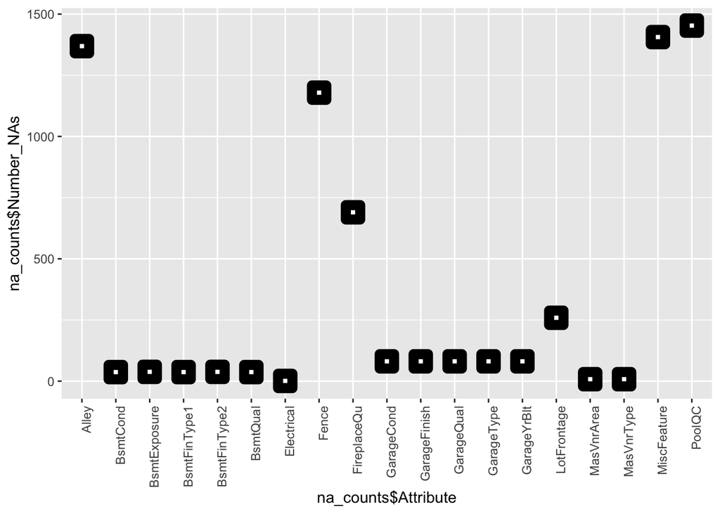

```r
ggplot(na_counts, aes(na_counts$Attribute, na_counts$Number_NAs)) +
  geom_point(shape = 22, colour = "black", fill = "white", size = 2, stroke = 5) +
  theme(axis.text.x = element_text(angle = 90, hjust = 1))
```

## Count Duplicates

```r
dup_rows <- train[duplicated(train),]
```

There are 0 duplicated observations.

## Convert to Factors / Separate Fact from Numeric

### Convert and Create

Convert characters to factors and create training sets for catagorial and numerical data.

```r
train[,(cat_var) := lapply(.SD, as.factor), .SDcols = cat_var]

train_cat <- train[,.SD, .SDcols = cat_var]
train_cont <- train[,.SD,.SDcols = numeric_var,]
```

### Structure

```r
str(train)
```

```
## Classes 'data.table' and 'data.frame':   1460 obs. of  81 variables:
##  $ Id           : int  1 2 3 4 5 6 7 8 9 10 ...
##  $ MSSubClass   : int  60 20 60 70 60 50 20 60 50 190 ...
##  $ MSZoning     : Factor w/ 5 levels "C (all)","FV",..: 4 4 4 4 4 4 4 4 5 4 ...
##  $ LotFrontage  : int  65 80 68 60 84 85 75 NA 51 50 ...
##  $ LotArea      : int  8450 9600 11250 9550 14260 14115 10084 10382 6120 7420 ...
##  $ Street       : Factor w/ 2 levels "Grvl","Pave": 2 2 2 2 2 2 2 2 2 2 ...
##  $ Alley        : Factor w/ 2 levels "Grvl","Pave": NA NA NA NA NA NA NA NA NA NA ...
##  $ LotShape     : Factor w/ 4 levels "IR1","IR2","IR3",..: 4 4 1 1 1 1 4 1 4 4 ...
##  $ LandContour  : Factor w/ 4 levels "Bnk","HLS","Low",..: 4 4 4 4 4 4 4 4 4 4 ...
##  $ Utilities    : Factor w/ 2 levels "AllPub","NoSeWa": 1 1 1 1 1 1 1 1 1 1 ...
##  $ LotConfig    : Factor w/ 5 levels "Corner","CulDSac",..: 5 3 5 1 3 5 5 1 5 1 ...
##  $ LandSlope    : Factor w/ 3 levels "Gtl","Mod","Sev": 1 1 1 1 1 1 1 1 1 1 ...
##  $ Neighborhood : Factor w/ 25 levels "Blmngtn","Blueste",..: 6 25 6 7 14 12 21 17 18 4 ...
##  $ Condition1   : Factor w/ 9 levels "Artery","Feedr",..: 3 2 3 3 3 3 3 5 1 1 ...
```

[output cut: 68 more lines]

## Plot Bar/Histograms

### Numeric

**Note* Create function to iterate next.**

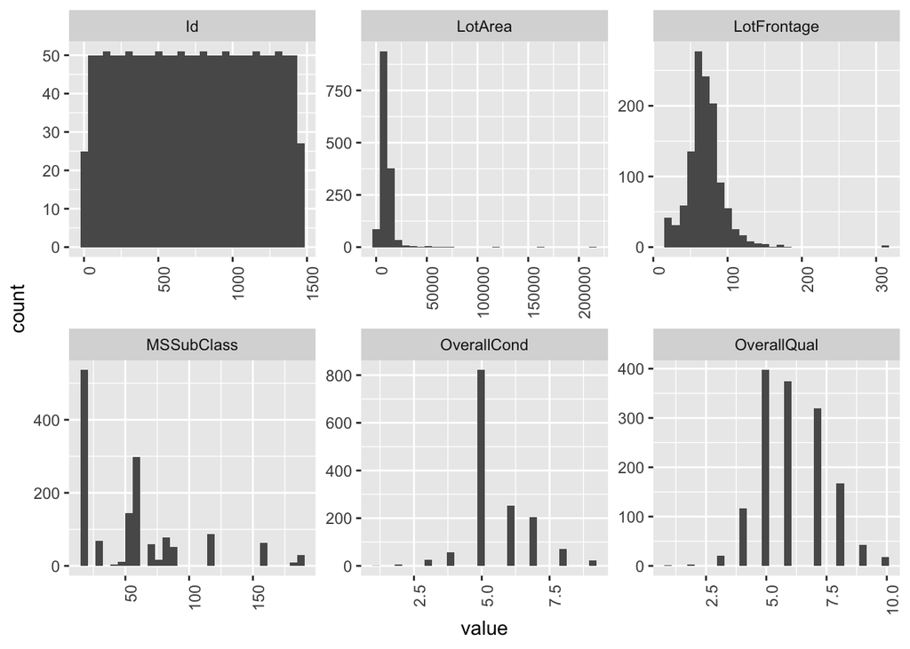

```r
train_cont[,1:6] %>%
  purrr::keep(is.numeric) %>%
  gather() %>%
  ggplot(aes(value)) +
    facet_wrap(~ key, scales = "free") +
    geom_histogram() +   theme(axis.text.x = element_text(angle = 90, hjust = 1))
```

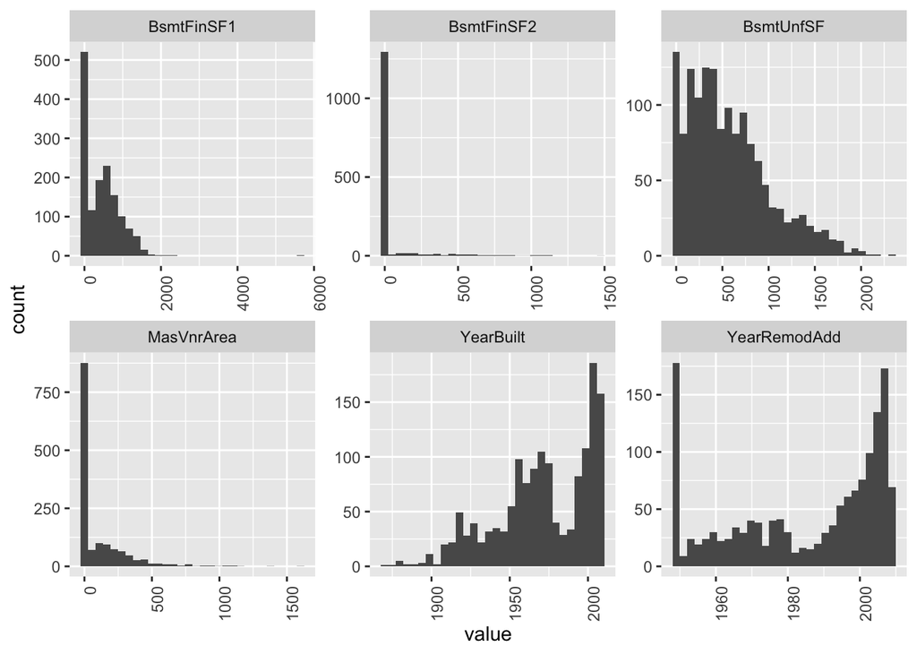

```r
train_cont[,7:12] %>%
  purrr::keep(is.numeric) %>%
  gather() %>%
  ggplot(aes(value)) +
    facet_wrap(~ key, scales = "free") +
    geom_histogram() +   theme(axis.text.x = element_text(angle = 90, hjust = 1))
```

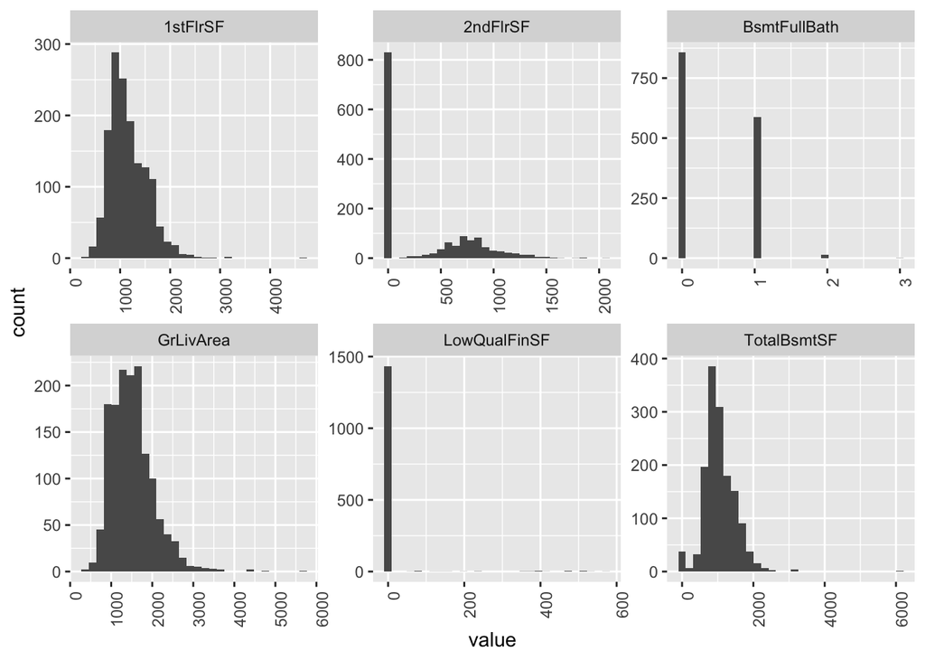

```r
train_cont[,13:18] %>%
  purrr::keep(is.numeric) %>%
  gather() %>%
  ggplot(aes(value)) +
    facet_wrap(~ key, scales = "free") +
    geom_histogram() +   theme(axis.text.x = element_text(angle = 90, hjust = 1))
```

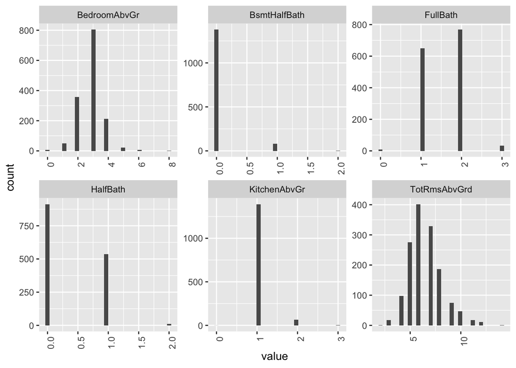

```r
train_cont[,19:24] %>%
  purrr::keep(is.numeric) %>%
  gather() %>%
  ggplot(aes(value)) +
    facet_wrap(~ key, scales = "free") +
    geom_histogram() +   theme(axis.text.x = element_text(angle = 90, hjust = 1))
```

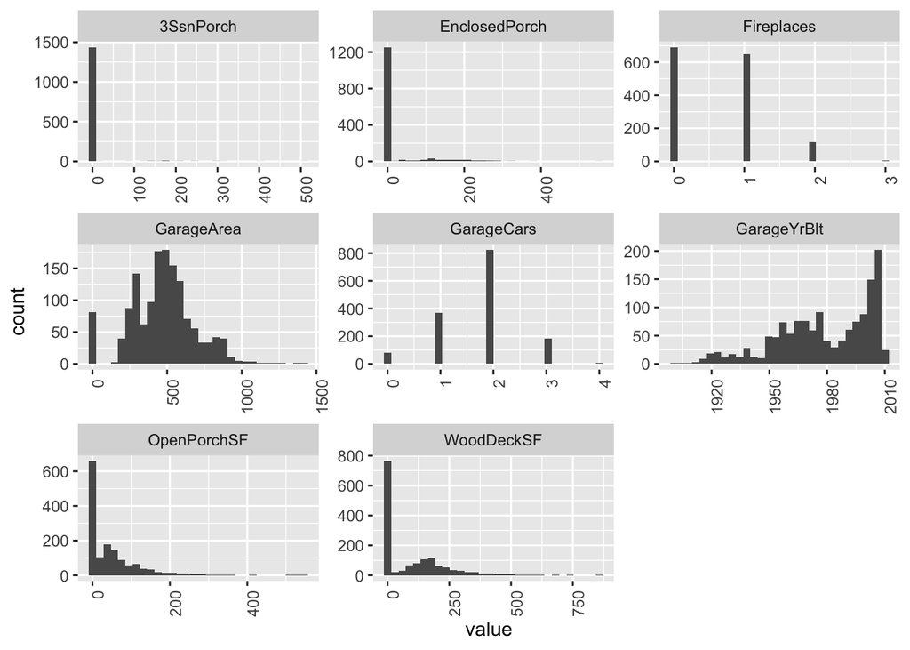

```r
train_cont[,25:32] %>%
  purrr::keep(is.numeric) %>%
  gather() %>%
  ggplot(aes(value)) +
    facet_wrap(~ key, scales = "free") +
    geom_histogram() +   theme(axis.text.x = element_text(angle = 90, hjust = 1))
```

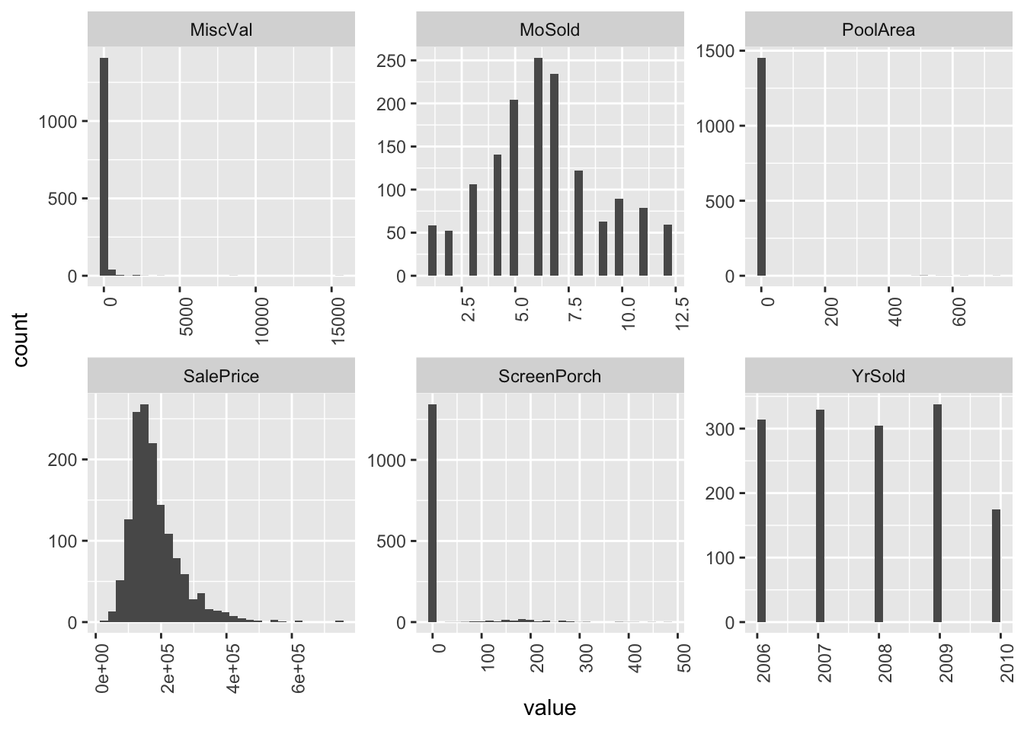

```r
train_cont[,33:38] %>%
  purrr::keep(is.numeric) %>%
  gather() %>%
  ggplot(aes(value)) +
    facet_wrap(~ key, scales = "free") +
    geom_histogram() +   theme(axis.text.x = element_text(angle = 90, hjust = 1))
```

### Catagorical

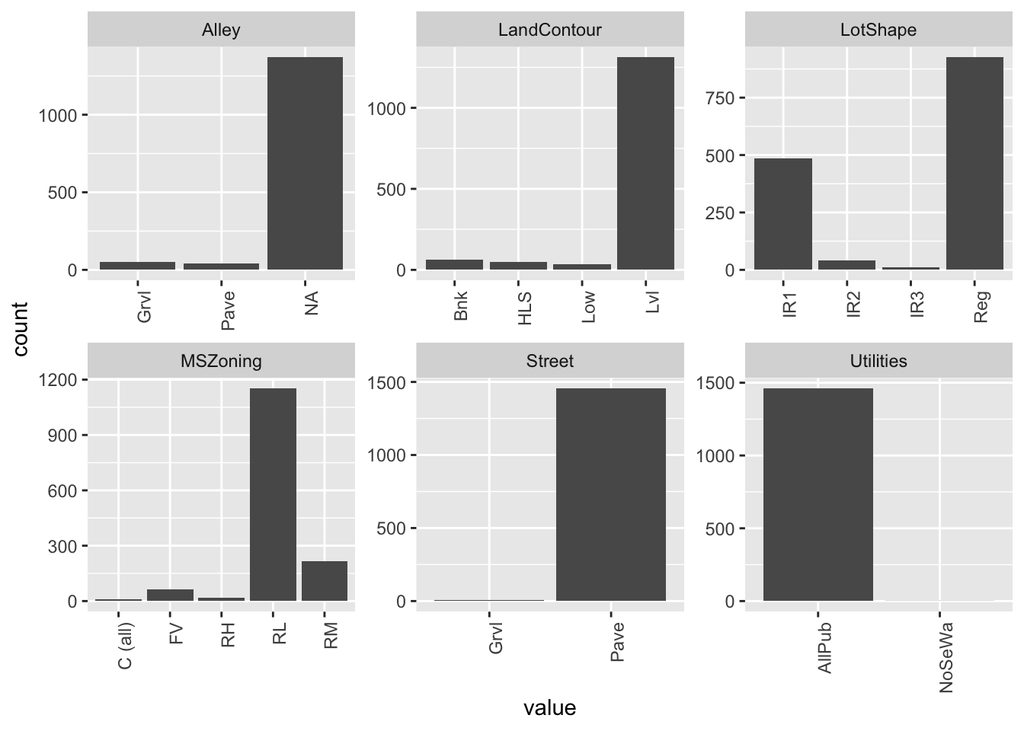

```r
train_cat[, 1:6] %>%
  gather() %>%
  ggplot(aes(value)) + stat_count() +
    facet_wrap(~ key, scales = "free") +   theme(axis.text.x = element_text(angle = 90, hjust = 1))
```

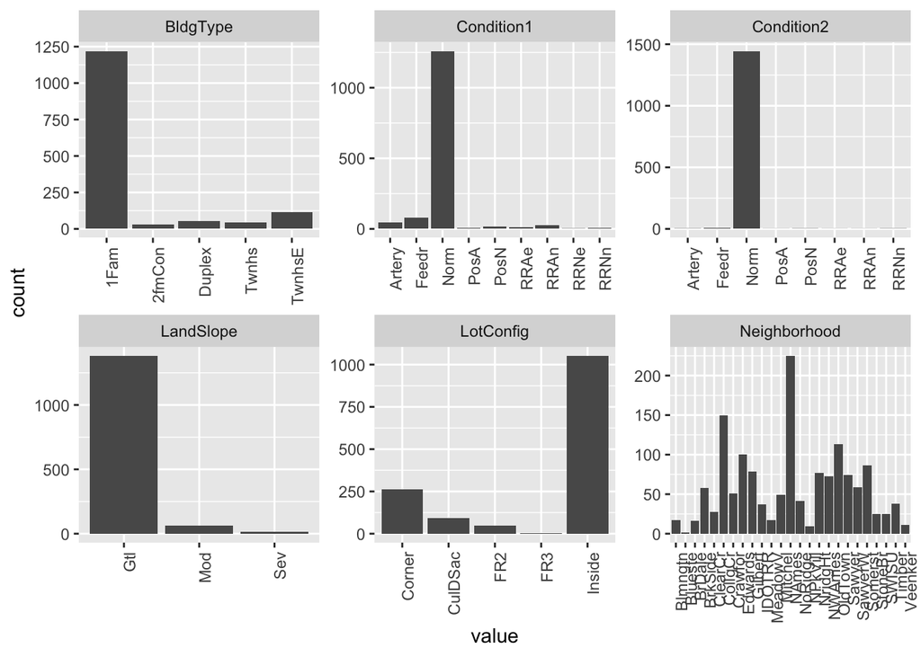

```r
train_cat[, 7:12] %>%
  gather() %>%
  ggplot(aes(value)) + stat_count() +
    facet_wrap(~ key, scales = "free") +   theme(axis.text.x = element_text(angle = 90, hjust = 1))
```

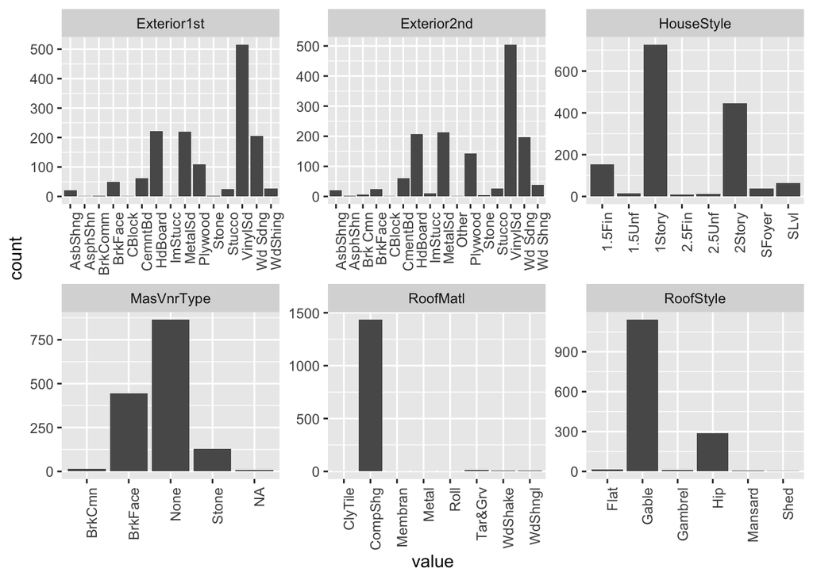

```r
train_cat[, 13:18] %>%
  gather() %>%
  ggplot(aes(value)) + stat_count() +
    facet_wrap(~ key, scales = "free") +   theme(axis.text.x = element_text(angle = 90, hjust = 1))
```

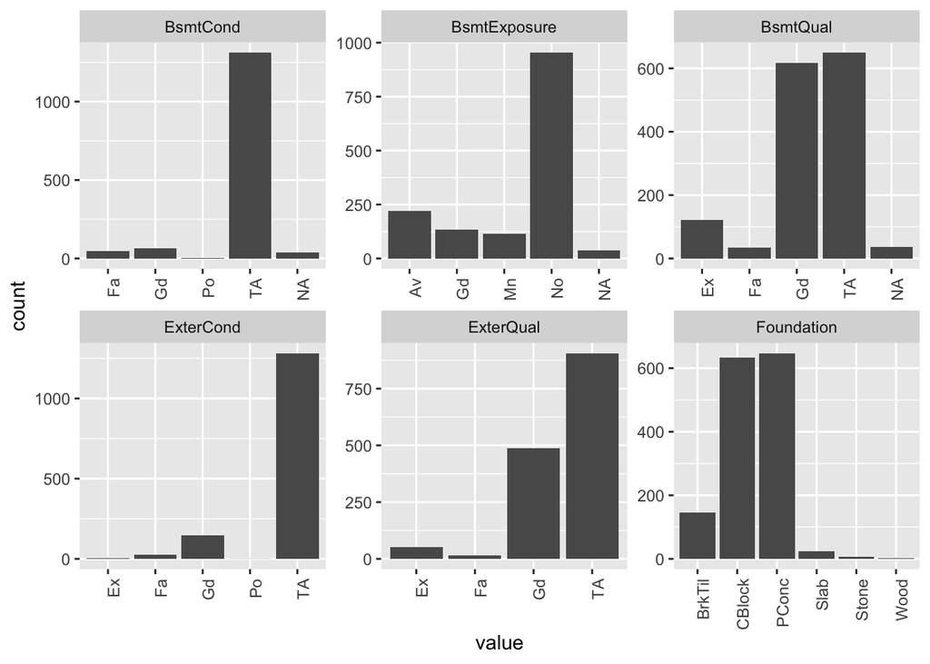

```r
train_cat[, 19:24] %>%
  gather() %>%
  ggplot(aes(value)) + stat_count() +
    facet_wrap(~ key, scales = "free") +   theme(axis.text.x = element_text(angle = 90, hjust = 1))
```

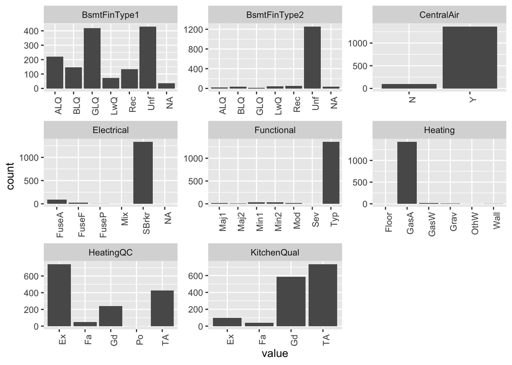

```r
train_cat[, 25:32] %>%
  gather() %>%
  ggplot(aes(value)) + stat_count() +
    facet_wrap(~ key, scales = "free") +   theme(axis.text.x = element_text(angle = 90, hjust = 1))
```

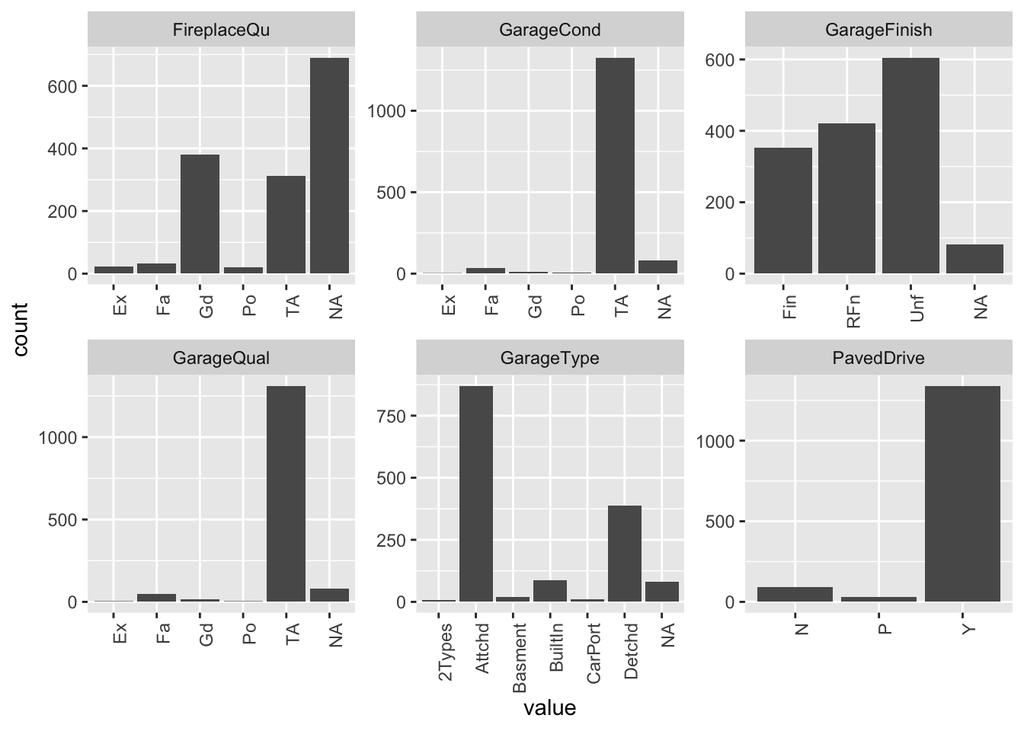

```r
train_cat[, 33:38] %>%
  gather() %>%
  ggplot(aes(value)) + stat_count() +
    facet_wrap(~ key, scales = "free") +   theme(axis.text.x = element_text(angle = 90, hjust = 1))
```

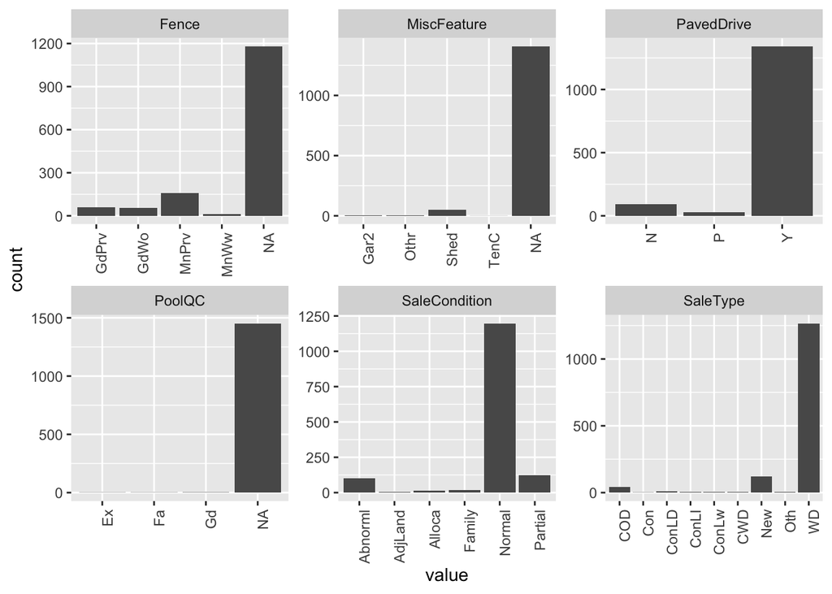

```r
train_cat[, 38:43] %>%
  gather() %>%
  ggplot(aes(value)) + stat_count() +
    facet_wrap(~ key, scales = "free") +   theme(axis.text.x = element_text(angle = 90, hjust = 1))
```

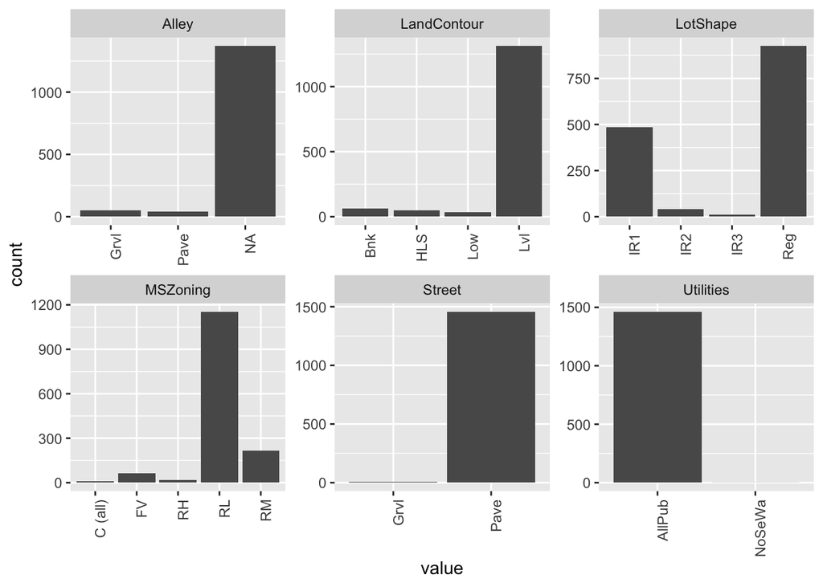

```r
train_cat[, 1:6] %>%
  gather() %>%
  ggplot(aes(value)) + stat_count() +
    facet_wrap(~ key, scales = "free") +   theme(axis.text.x = element_text(angle = 90, hjust = 1))
```

### Missing Data2

This plot shows the intersection of missing data as well as the populations of missing data.

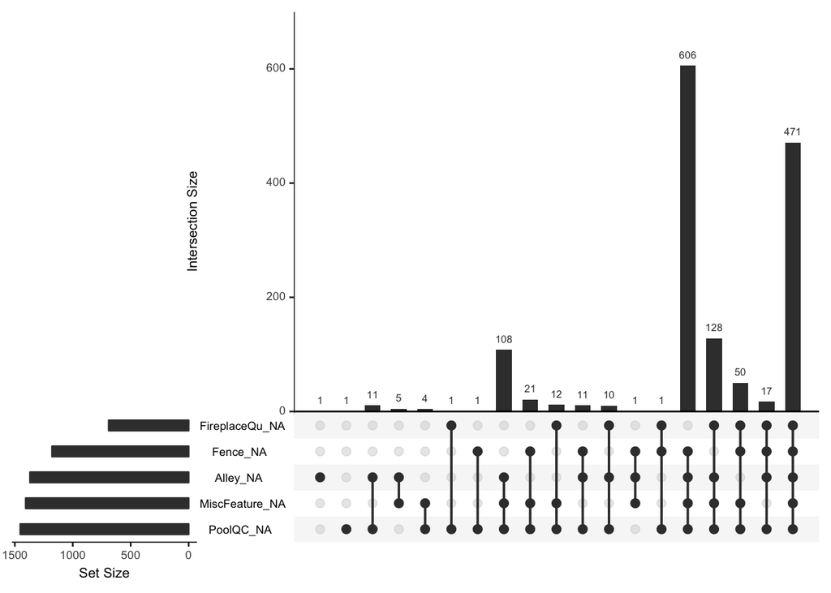

```r
library(naniar)
library(UpSetR)
var_w_miss_data <- n_var_miss(train)

train %>%
  as_shadow_upset() %>%
  upset()
```